# Homework 4 - Working with large datasets

Eunchong Kang

02/12/2022

Library setup

# Question 1 - benchmark data.table’s grouping on real data

0. Import data as data.table

```r
dt <- fread("../Scorecard_2009-2016.csv")
dt2 <- dt
```

1. Modify data types with the level

   ```
    | C | Value              |     |
    |---|--------------------|-----|
    | 1 | Public             | pub |
    | 2 | Private nonprofit  | pnp |
    | 3 | Private for-profit | pfp |
   ```

```r
dt2$TUITFTE <- as.numeric(dt2$TUITFTE)
dt2$SAT_AVG <- as.numeric(dt2$SAT_AVG)
dt2$CONTROL <- as.factor(dt2$CONTROL)
levels(dt2$CONTROL) <- c("pub", "pnp", "pfp")
```

2. Tabulate the number of schools by `CONTROL` with or without non-NA values for both `TUITFTE` *and* `SAT_AVG`.

```r
# The number of schools by CONTROL
dt2[, .N, by = CONTROL]
```

```
##    CONTROL     N
## 1:     pub 18638
## 2:     pnp 17718
## 3:     pfp 31062
```

```r
# The numbet of schools by CONTROL that have non-NA values for TUITFTE and SAT_AVG
dt2[TUITFTE != "NA" & SAT_AVG != "NA", .N, by = CONTROL]
```

```
##    CONTROL    N
## 1:     pub 4673
## 2:     pnp 7523
## 3:     pfp   89
```

```r
# or dt2[!is.na(TUITFTE) & !is.na(SAT_AVG), .N, by = CONTROL]
```

3. Compute the mean and SD of `TUITFTE` and `SAT_AVG` by `CONTROL`.

```r
# My NA-removed mean and sd function
mean_NA_removed <- function(x){
        return(mean(x[!is.na(x)]))
}
sd_NA_removed <- function(x){
        return(sd(x[!is.na(x)]))
}

# Using data.table
dt2[,
    .(TUITFTE_mean=mean_NA_removed(TUITFTE), SAT_AVG_mean=mean_NA_removed(SAT_AVG),
      TUITFTE_sd=sd_NA_removed(TUITFTE), SAT_AVG_sd=sd_NA_removed(SAT_AVG)),
    by = CONTROL]
```

```
##    CONTROL TUITFTE_mean SAT_AVG_mean TUITFTE_sd SAT_AVG_sd
## 1:     pub     4228.865     1042.886   5056.246   113.0328
## 2:     pnp    14265.358     1079.230  24634.090   143.4723
## 3:     pfp    10661.401     1004.360  10945.809   112.9672
```

```r
# Using aggregate
merge(aggregate(dt2[, c("TUITFTE", "SAT_AVG")], dt2[, "CONTROL"], mean_NA_removed),
      aggregate(dt2[, c("TUITFTE", "SAT_AVG")], dt2[, "CONTROL"], sd_NA_removed),
      by = "CONTROL", suffixes = c("_mean", "_sd"), sort = FALSE)
```

```
##   CONTROL TUITFTE_mean SAT_AVG_mean TUITFTE_sd SAT_AVG_sd
## 1     pub     4228.865     1042.886   5056.246   113.0328
## 2     pnp    14265.358     1079.230  24634.090   143.4723
## 3     pfp    10661.401     1004.360  10945.809   112.9672
```

```r
# Compare two methods
microbenchmark(dt2[,
                   .(TUITFTE_mean=mean_NA_removed(TUITFTE), SAT_AVG_mean=mean_NA_removed(SAT_AVG),
                     TUITFTE_sd=sd_NA_removed(TUITFTE), SAT_AVG_sd=sd_NA_removed(SAT_AVG)),
                   by = CONTROL],
               merge(aggregate(dt2[, c("TUITFTE", "SAT_AVG")], dt2[, "CONTROL"], mean_NA_removed),
                     aggregate(dt2[, c("TUITFTE", "SAT_AVG")], dt2[, "CONTROL"], sd_NA_removed),
                     by = "CONTROL", suffixes = c("_mean", "_sd"), sort = FALSE),
               times = 10)
```

```
## Unit: milliseconds
##                                                                                                                                                                                                                                        expr
##                                                dt2[, .(TUITFTE_mean = mean_NA_removed(TUITFTE), SAT_AVG_mean = mean_NA_removed(SAT_AVG),      TUITFTE_sd = sd_NA_removed(TUITFTE), SAT_AVG_sd = sd_NA_removed(SAT_AVG)),      by = CONTROL]
##  merge(aggregate(dt2[, c("TUITFTE", "SAT_AVG")], dt2[, "CONTROL"],      mean_NA_removed), aggregate(dt2[, c("TUITFTE", "SAT_AVG")],      dt2[, "CONTROL"], sd_NA_removed), by = "CONTROL", suffixes = c("_mean",      "_sd"), sort = FALSE)
##      min      lq     mean  median      uq    max neval
##   8.2266  8.8523  8.98173  8.9859  9.2849  9.421    10
##  65.3367 65.6808 66.66964 66.1126 66.8263 71.731    10
```

# Question 2- doing more with “by” in data.table

1. Make `scores.sub`

```r
# Making `scores.sub`
scores.sub <- na.omit(dt2, cols=c("TUITFTE", "SAT_AVG"))
```

2. Make a plot of `SAT_AVG` over `TUITFTE`

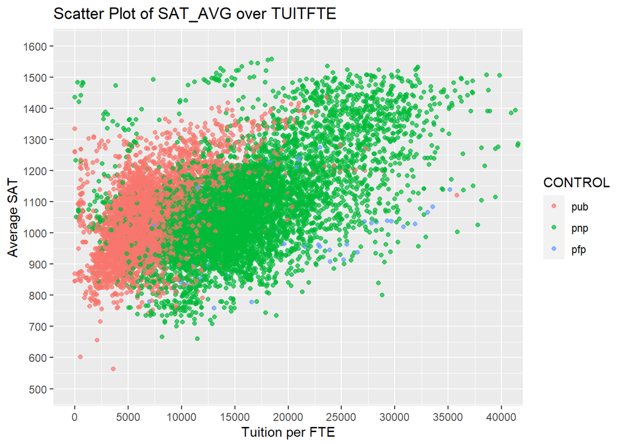

```r
# Making a plot
ggplot(scores.sub, aes(TUITFTE, SAT_AVG)) +
        geom_point(aes(color= CONTROL), alpha = 0.7, position = "jitter") +
        ggtitle("Scatter Plot of SAT_AVG over TUITFTE") +
        coord_cartesian(xlim=c(0,40000), ylim=c(500,1600)) +
        labs(x= "Tuition per FTE", y="Average SAT") +
        scale_x_continuous(breaks=seq(0, 40000, 5000)) +
        scale_y_continuous(breaks=seq(500, 1600, 100))
```

3. Tabulate the number of schools that have tuition per FTE over 20,000 and/or average SAT over 1200, grouped by ownership category.

```r
scores.sub[, .N, keyby = .(CONTROL,
                        TUITFTE_over20000 = TUITFTE > 20000,
                        SAT_AVG_over1200 = SAT_AVG > 1200)]
```

```
##     CONTROL TUITFTE_over20000 SAT_AVG_over1200    N
##  1:     pub             FALSE            FALSE 4207
##  2:     pub             FALSE             TRUE  437
##  3:     pub              TRUE            FALSE   12
##  4:     pub              TRUE             TRUE   17
##  5:     pnp             FALSE            FALSE 5648
##  6:     pnp             FALSE             TRUE  411
##  7:     pnp              TRUE            FALSE  611
##  8:     pnp              TRUE             TRUE  853
##  9:     pfp             FALSE            FALSE   61
## 10:     pfp             FALSE             TRUE    2
## 11:     pfp              TRUE            FALSE   22
## 12:     pfp              TRUE             TRUE    4
```

# Question 3 - subsets of data

```r
scores.sub[, .(CONTROL, TUITFTE, SAT_AVG)][order(-SAT_AVG)][, head(.SD, 1), keyby = CONTROL]
```

```
##    CONTROL TUITFTE SAT_AVG
## 1:     pub   23581    1436
## 2:     pnp   18456    1558
## 3:     pfp   22998    1274
```

# Question 4 - MovieLens sparse dataset

0. Importing data

```r
links <- read_csv("../ml-latest-small/links.csv")
movies <- read_csv("../ml-latest-small/movies.csv")
ratings <- read_csv("../ml-latest-small/ratings.csv")
tags <- read_csv("../ml-latest-small/tags.csv")
```

1. How many of the movies have the “Comedy” genre attached to them?

```r
sum(grepl("Comedy", movies$genres))
```

```
## [1] 3756
```

2. Build a sparse matrix of the movies by users and investigate the range, quartiles, etc. of number of movies rated by each user.

```r
# Making sparse matrix of movies by user.
mtrx <- sparseMatrix(ratings$movieId, ratings$userId, x=1)
mtrx_ratings <- mtrx[rowSums(mtrx) != 0,]
dim(mtrx_ratings)
```

```
## [1] 9724  610
```

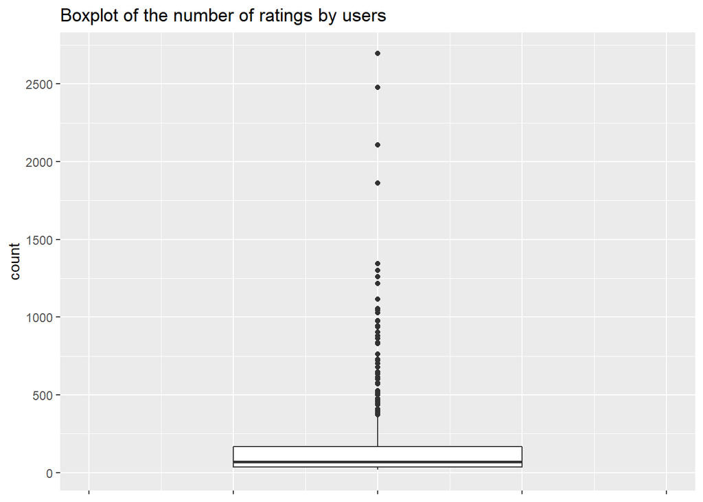

```r
# Summary
summary <- summary(mtrx_ratings) %>%
        group_by(j) %>%
        summarise(count = n())
ggplot(summary, aes(y=count)) +
                geom_boxplot(width=1) +
                scale_x_continuous(limits = c(-1, 1)) +
                scale_y_continuous(breaks=seq(0, 3000, 500)) +
                ggtitle("Boxplot of the number of ratings by users") +
                theme(axis.text.x=element_blank())
```

```r
summary(summary$count)
```

```
##    Min. 1st Qu.  Median    Mean 3rd Qu.    Max.
##    20.0    35.0    70.5   165.3   168.0  2698.0
```

3. Compute SVD

```r
# Making key variable to match the spare matrix row number to movieId
keys <- data.frame(movieId = unique(ratings$movieId), key = 1:9724)
keys_byRow <- left_join(keys, movies, by="movieId")

# Computing SVD
svd <- sparsesvd(mtrx_ratings, rank=3)
dim(svd$u)
```

```
## [1] 9724    3
```

4. Plot the columns of the U matrix against each other: 1 vs 2, 2 vs 3, 1 vs 3.

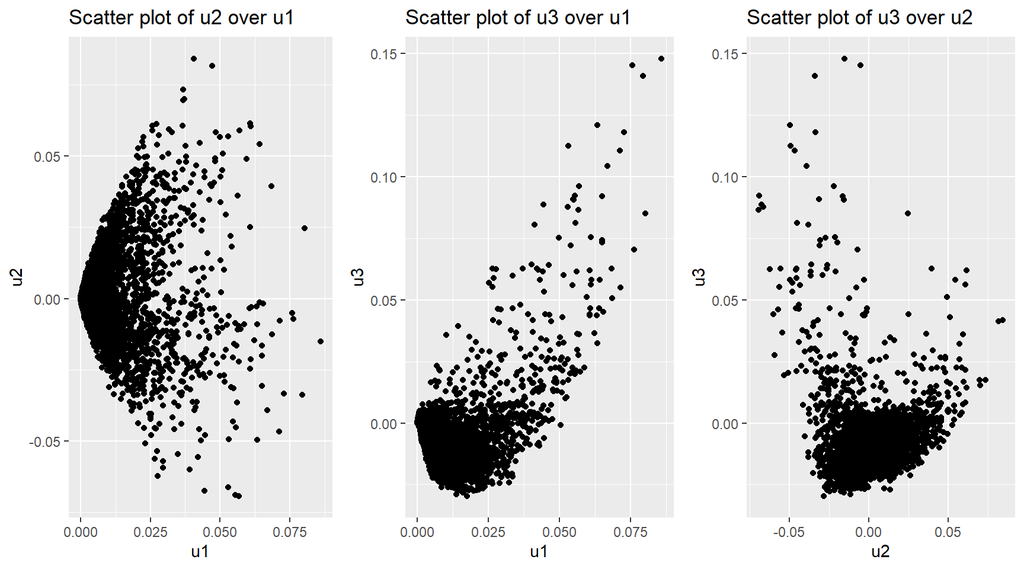

```r
# Change svd matrix to data.frame with key variable
svd_df <- data.frame(svd$u) %>%
        mutate(key = 1:nrow(svd$u)) %>%
        rename("u1"="X1", "u2"="X2", "u3"="X3")

plot_1_2 <- ggplot(svd_df, aes(u1, u2)) +
        geom_point() +
        ggtitle("Scatter plot of u2 over u1")

plot_1_3 <- ggplot(svd_df, aes(u1, u3)) +
        geom_point() +
        ggtitle("Scatter plot of u3 over u1")

plot_2_3 <- ggplot(svd_df, aes(u2, u3)) +
        geom_point() +
        ggtitle("Scatter plot of u3 over u2")

grid.arrange(plot_1_2, plot_1_3, plot_2_3, nrow = 1, ncol = 3)
```

5. Investigate the names of these movies. What property can you infer about the top 6 movies in the tail w.r.t. column 1 and 3.

```r
# Top 6 moives w.r.t the sum of u1 and u3
df_movies_key_u <- left_join(keys_byRow, svd_df, by="key")
df_movies_key_u %>% mutate(sum_u1_u3 = u1 + u3) %>%
                        arrange(desc(sum_u1_u3)) %>%
                        head(n=6)
```

```
##   movieId key                      title                           genres
## 1     368 315            Maverick (1994)         Adventure|Comedy|Western
## 2    3949 278 Requiem for a Dream (2000)                            Drama
## 3  122882 258  Mad Max: Fury Road (2015) Action|Adventure|Sci-Fi|Thriller
## 4      87 511   Dunston Checks In (1996)                  Children|Comedy
## 5    1500  98 Grosse Pointe Blank (1997)             Comedy|Crime|Romance
## 6    3317 419         Wonder Boys (2000)                     Comedy|Drama
##           u1           u2        u3 sum_u1_u3
## 1 0.08594751 -0.015190087 0.1478395 0.2337870
## 2 0.07575892 -0.005197072 0.1451960 0.2209550
## 3 0.07946163 -0.033868596 0.1407425 0.2202041
## 4 0.07284396 -0.033477930 0.1179791 0.1908230
## 5 0.06330308 -0.049554150 0.1207891 0.1840922
## 6 0.07124448 -0.046838411 0.1105438 0.1817882
```

6. Look at the extremes of column 2 of U.

```r
# Extremes of u2
# Largest
df_movies_key_u %>% arrange(desc(u2)) %>%
                        head(n=5)
```

```
##   movieId  key                            title                  genres
## 1   31737 7356     Bunny Lake Is Missing (1965)        Mystery|Thriller
## 2    5398 6694 Requiem for a Heavyweight (1962)                   Drama
## 3   90353 7023             Beautiful Boy (2010)                   Drama
## 4  169982 7196             Power Rangers (2017) Action|Adventure|Sci-Fi
## 5     773 6727               Touki Bouki (1973)                   Drama
##           u1         u2         u3
## 1 0.04060145 0.08430504 0.04162804
## 2 0.04707720 0.08177083 0.04122820
## 3 0.03680570 0.07330762 0.01746731
## 4 0.03718459 0.07008500 0.01525863
## 5 0.03684095 0.06971217 0.01743912
```

```r
# Smallest
df_movies_key_u %>% arrange(u2) %>%
                        head(n=5)
```

```
##   movieId key                                                      title
## 1      86 510                                        White Squall (1996)
## 2    2599 399                                            Election (1999)
## 3      79 509                                          Juror, The (1996)
## 4     930 338                                           Notorious (1946)
## 5     265 308 Like Water for Chocolate (Como agua para chocolate) (1992)
##                       genres         u1          u2         u3
## 1     Action|Adventure|Drama 0.05665996 -0.06934040 0.08645253
## 2                     Comedy 0.05545388 -0.06895428 0.09231792
## 3             Drama|Thriller 0.04442100 -0.06765370 0.08857444
## 4 Film-Noir|Romance|Thriller 0.05296751 -0.06634746 0.08760294
## 5      Drama|Fantasy|Romance 0.02762397 -0.06233639 0.06242236
```

- comments: The movies with the highest values in both u1 and u3 have the same characterstics of the two corresponding latent factors. It is difficult for me to infer some property to be shared by those movies when considering its name and genre. Similarly, one can sort movies by a latent factor represented by u2. It is hard to tell the differences between the largest and smallest groups with regard to u2.